# An Exploratory Analysis of Loan Data from Prosper

## Introduction

> This notebook will document my efforts to exploratory analyze data from Prosper MarketPlace, a peer to peer lending industry. This data set contains 113,937 loans with 81 variables on each loan, including loan amount, borrower rate (or interest rate), current loan status, borrower income, and many others.

## Preliminary Wrangling

```python
# import all packages and set plots to be embedded inline
import numpy as np
import pandas as pd
import matplotlib.pyplot as plt
import seaborn as sb
import warnings
warnings.filterwarnings('ignore')
%matplotlib inline
```

```python
#load in your dataset with pandas
prosperloan = pd.read_csv('prosperLoanData.csv', engine = 'python')
prosperloan.head()
```

|  | ListingKey | ListingNumber | ListingCreationDate | CreditGrade | Term | LoanStatus | ClosedDate | BorrowerAPR | BorrowerRate | LenderYield | ... | LP_ServiceFees | LP_CollectionFees | LP_GrossPrincipalLoss | LP_NetPrincipalLoss | LP_NonPrincipalRecoverypayments | PercentFunded | Recommendations | InvestmentFromFriendsCount | InvestmentFromFriendsAmount | Investors |
| --- | --- | --- | --- | --- | --- | --- | --- | --- | --- | --- | --- | --- | --- | --- | --- | --- | --- | --- | --- | --- | --- |
| 0 | 1021339766868145413AB3B | 193129 | 2007-08-26 19:09:29.263000000 | C | 36 | Completed | 2009-08-14 00:00:00 | 0.16516 | 0.1580 | 0.1380 | ... | -133.18 | 0.0 | 0.0 | 0.0 | 0.0 | 1.0 | 0 | 0 | 0.0 | 258 |
| 1 | 10273602499503308B223C1 | 1209647 | 2014-02-27 08:28:07.900000000 | NaN | 36 | Current | NaN | 0.12016 | 0.0920 | 0.0820 | ... | 0.00 | 0.0 | 0.0 | 0.0 | 0.0 | 1.0 | 0 | 0 | 0.0 | 1 |
| 2 | 0EE9337825851032864889A | 81716 | 2007-01-05 15:00:47.090000000 | HR | 36 | Completed | 2009-12-17 00:00:00 | 0.28269 | 0.2750 | 0.2400 | ... | -24.20 | 0.0 | 0.0 | 0.0 | 0.0 | 1.0 | 0 | 0 | 0.0 | 41 |
| 3 | 0EF5356002482715299901A | 658116 | 2012-10-22 11:02:35.010000000 | NaN | 36 | Current | NaN | 0.12528 | 0.0974 | 0.0874 | ... | -108.01 | 0.0 | 0.0 | 0.0 | 0.0 | 1.0 | 0 | 0 | 0.0 | 158 |
| 4 | 0F023589499656230C5E3E2 | 909464 | 2013-09-14 18:38:39.097000000 | NaN | 36 | Current | NaN | 0.24614 | 0.2085 | 0.1985 | ... | -60.27 | 0.0 | 0.0 | 0.0 | 0.0 | 1.0 | 0 | 0 | 0.0 | 20 |

5 rows × 81 columns

```python
#get the structure of the dataset
prosperloan.shape
```

```
(113937, 81)
```

```python
#get a summary of the descriptive statistics of the dataframe
prosperloan.describe()
```

|  | ListingNumber | Term | BorrowerAPR | BorrowerRate | LenderYield | EstimatedEffectiveYield | EstimatedLoss | EstimatedReturn | ProsperRating (numeric) | ProsperScore | ... | LP_ServiceFees | LP_CollectionFees | LP_GrossPrincipalLoss | LP_NetPrincipalLoss | LP_NonPrincipalRecoverypayments | PercentFunded | Recommendations | InvestmentFromFriendsCount | InvestmentFromFriendsAmount | Investors |
| --- | --- | --- | --- | --- | --- | --- | --- | --- | --- | --- | --- | --- | --- | --- | --- | --- | --- | --- | --- | --- | --- |
| count | 1.139370e+05 | 113937.000000 | 113912.000000 | 113937.000000 | 113937.000000 | 84853.000000 | 84853.000000 | 84853.000000 | 84853.000000 | 84853.000000 | ... | 113937.000000 | 113937.000000 | 113937.000000 | 113937.000000 | 113937.000000 | 113937.000000 | 113937.000000 | 113937.000000 | 113937.000000 | 113937.000000 |
| mean | 6.278857e+05 | 40.830248 | 0.218828 | 0.192764 | 0.182701 | 0.168661 | 0.080306 | 0.096068 | 4.072243 | 5.950067 | ... | -54.725641 | -14.242698 | 700.446342 | 681.420499 | 25.142686 | 0.998584 | 0.048027 | 0.023460 | 16.550751 | 80.475228 |
| std | 3.280762e+05 | 10.436212 | 0.080364 | 0.074818 | 0.074516 | 0.068467 | 0.046764 | 0.030403 | 1.673227 | 2.376501 | ... | 60.675425 | 109.232758 | 2388.513831 | 2357.167068 | 275.657937 | 0.017919 | 0.332353 | 0.232412 | 294.545422 | 103.239020 |
| min | 4.000000e+00 | 12.000000 | 0.006530 | 0.000000 | -0.010000 | -0.182700 | 0.004900 | -0.182700 | 1.000000 | 1.000000 | ... | -664.870000 | -9274.750000 | -94.200000 | -954.550000 | 0.000000 | 0.700000 | 0.000000 | 0.000000 | 0.000000 | 1.000000 |
| 25% | 4.009190e+05 | 36.000000 | 0.156290 | 0.134000 | 0.124200 | 0.115670 | 0.042400 | 0.074080 | 3.000000 | 4.000000 | ... | -73.180000 | 0.000000 | 0.000000 | 0.000000 | 0.000000 | 1.000000 | 0.000000 | 0.000000 | 0.000000 | 2.000000 |
| 50% | 6.005540e+05 | 36.000000 | 0.209760 | 0.184000 | 0.173000 | 0.161500 | 0.072400 | 0.091700 | 4.000000 | 6.000000 | ... | -34.440000 | 0.000000 | 0.000000 | 0.000000 | 0.000000 | 1.000000 | 0.000000 | 0.000000 | 0.000000 | 44.000000 |
| 75% | 8.926340e+05 | 36.000000 | 0.283810 | 0.250000 | 0.240000 | 0.224300 | 0.112000 | 0.116600 | 5.000000 | 8.000000 | ... | -13.920000 | 0.000000 | 0.000000 | 0.000000 | 0.000000 | 1.000000 | 0.000000 | 0.000000 | 0.000000 | 115.000000 |
| max | 1.255725e+06 | 60.000000 | 0.512290 | 0.497500 | 0.492500 | 0.319900 | 0.366000 | 0.283700 | 7.000000 | 11.000000 | ... | 32.060000 | 0.000000 | 25000.000000 | 25000.000000 | 21117.900000 | 1.012500 | 39.000000 | 33.000000 | 25000.000000 | 1189.000000 |

8 rows × 61 columns

```python
#check for duplicated variables
prosperloan.duplicated().any()
```

```
False
```

### What is the structure of your dataset?

> This dataset has 113937 observations and 81 variables. The data set has no duplicate records.

### What is/are the main feature(s) of interest in your dataset?

> The main features I will be focusing on in this analysis are:
> - **ProsperRating(alpha)**: The Prosper Rating assigned at the time the listing was created between AA - HR. Applicable for loans originated after July 2009.
> - **CreditGrade**: The Credit rating that was assigned at the time the listing went live. Applicable for listings pre-2009 period and will only be populated for those listings.
> - **IncomeRange**: The income range of the borrower at the time the listing was created.
> - **BorrowerAPR**: The Borrower's Annual Percentage Rate (APR) for the loan.
> - **EmploymentStatus**: The employment status of the borrower at the time they posted the listing.
> - **LoanStatus**: The current status of the loan: Cancelled, Chargedoff, Completed, Current, Defaulted, FinalPaymentInProgress, PastDue. The PastDue status will be accompanied by a delinquency bucket.
> - **MonthlyLoanPayment:** The scheduled monthly loan payment.

### What features in the dataset do you think will help support your investigation into your feature(s) of interest?

> The features that will help support my investigation into the main feautures are:
> - **BorrowerRate**: The Borrower's interest rate for this loan.
> - **StatedMonthlyIncome**: The monthly income the borrower stated at the time the listing was created.
> - **DebtToIncomeRatio**: The debt to income ratio of the borrower at the time the credit profile was pulled. This value is Null if the debt to income ratio is not available. This value is capped at 10.01 (any debt to income ratio larger than 1000% will be returned as 1001%).
> - **LP_GrossPrincipalLoss**: The gross charged off amount of the loan.
> - **LoanOriginalAmount**: The origination amount of the loan.
> - **EstimatedReturn**: The estimated return assigned to the listing at the time it was created. Estimated return is the difference between the Estimated Effective Yield and the Estimated Loss Rate. Applicable for loans originated after July 2009.
> - **LoanOriginationDate**: The date the loan was originated.
> - **Term**: The length of the loan expressed in months.
> - **IsBorrowerHomeowner**: A Borrower will be classified as a homowner if they have a mortgage on their credit profile or provide documentation confirming they are a homeowner.

# Assessing & Cleaning Data

### The Nulls in the dataset

This dataset consist of a lot of null values. Most rightfully so. For some variables, they only apply to loans pre July 2009 like creditGrade, some only apply to loans post July 2009 like EstimatedEffectiveYield, EstimatedLoss, EstimatedReturn, ProsperRating (numeric), ProsperRating (Alpha), ProsperScore. Some of the variables are also not applicable to all borrowers like GroupKey, CurrentCreditLines, OpenCreditLines, FirstRecordedCreditLine, InquiriesLast6months, DebtToIncomeRatio etc.

Theres not a lot to do with the nans in this dataset because of these reasons but for columns like the BorrowerAPR that can be calculated, I will be doing so in my analysis. I will also be dropping the columns that I woud not be using for the analysis.

#### Addressing the Nans in the BorrowerAPR column

```python
#get look at the structure of the dataset
prosperloan.shape
```

```
(113937, 81)
```

```python
#get a summary of the dataset
prosperloan.info()
```

```
<class 'pandas.core.frame.DataFrame'>
RangeIndex: 113937 entries, 0 to 113936
Data columns (total 81 columns):
ListingKey                             113937 non-null object
ListingNumber                          113937 non-null int64
ListingCreationDate                    113937 non-null object
CreditGrade                            28953 non-null object
Term                                   113937 non-null int64
LoanStatus                             113937 non-null object
ClosedDate                             55089 non-null object
BorrowerAPR                            113912 non-null float64
BorrowerRate                           113937 non-null float64
LenderYield                            113937 non-null float64
EstimatedEffectiveYield                84853 non-null float64
EstimatedLoss                          84853 non-null float64
EstimatedReturn                        84853 non-null float64
ProsperRating (numeric)                84853 non-null float64
ProsperRating (Alpha)                  84853 non-null object
ProsperScore                           84853 non-null float64
ListingCategory (numeric)              113937 non-null int64
BorrowerState                          108422 non-null object
Occupation                             110349 non-null object
EmploymentStatus                       111682 non-null object
EmploymentStatusDuration               106312 non-null float64
IsBorrowerHomeowner                    113937 non-null bool
CurrentlyInGroup                       113937 non-null bool
GroupKey                               13341 non-null object
DateCreditPulled                       113937 non-null object
CreditScoreRangeLower                  113346 non-null float64
CreditScoreRangeUpper                  113346 non-null float64
FirstRecordedCreditLine                113240 non-null object
CurrentCreditLines                     106333 non-null float64
OpenCreditLines                        106333 non-null float64
TotalCreditLinespast7years             113240 non-null float64
OpenRevolvingAccounts                  113937 non-null int64
OpenRevolvingMonthlyPayment            113937 non-null float64
InquiriesLast6Months                   113240 non-null float64
TotalInquiries                         112778 non-null float64
CurrentDelinquencies                   113240 non-null float64
AmountDelinquent                       106315 non-null float64
```

[output cut: 31 more lines]

```
LP_CustomerPayments                    113937 non-null float64
LP_CustomerPrincipalPayments           113937 non-null float64
LP_InterestandFees                     113937 non-null float64
LP_ServiceFees                         113937 non-null float64
LP_CollectionFees                      113937 non-null float64
LP_GrossPrincipalLoss                  113937 non-null float64
LP_NetPrincipalLoss                    113937 non-null float64
LP_NonPrincipalRecoverypayments        113937 non-null float64
PercentFunded                          113937 non-null float64
Recommendations                        113937 non-null int64
InvestmentFromFriendsCount             113937 non-null int64
InvestmentFromFriendsAmount            113937 non-null float64
Investors                              113937 non-null int64
dtypes: bool(3), float64(50), int64(11), object(17)
memory usage: 68.1+ MB
```

```python
#check for null values in the BorrowerAPR column
prosperloan['BorrowerAPR'].isnull().sum()
```

```
25
```

```python
#check for null values in the BorrowerRate column
prosperloan['BorrowerRate'].isnull().any()
```

```
False
```

There are 25 null values in the BorrowerAPR column.After a google search I found out that the Annual Percentage Rate (APR) is the cost you pay each year to borrow money, including fees, expressed as a percentage. So the BorrowerAPR = BorrowerRate + fees. Since we have the BorrowerRate for these missing BorrowerAPR's, I will be estimating the APR by adding the average borrower fee to each missing APR's borrower rate.

```python
#find the average borrower fee of the dataset
borrowerfee = prosperloan["BorrowerAPR"] - prosperloan["BorrowerRate"]
borrowerfee.mean()
```

```
0.026041364737692252
```

```python
#fill the null values with the summation of borrower rate and the mean borrowerfee
prosperloan["BorrowerAPR"].fillna(prosperloan["BorrowerRate"] + borrowerfee.mean(), inplace=True)
```

```python
#check if there a null values
prosperloan['BorrowerAPR'].isnull().any()
```

```
False
```

#### Drop columns not needed for the analysis

```python
#drop columns that won't be needed for this analysis
prosperloan.drop(['Recommendations', 'InvestmentFromFriendsCount', 'InvestmentFromFriendsAmount', 'PercentFunded', 'PublicRecordsLast10Years', 'PublicRecordsLast12Months'], axis = 1, inplace=True)
```

#### There's alreading a category of employment status called not available, so i will be replacing the null values with not available.

```python
#check for null values in the employmentstatus column
prosperloan['EmploymentStatus'].isnull().any()
```

```
True
```

```python
#fill nulls with not available
prosperloan['EmploymentStatus'].fillna('Not available', inplace=True)
```

```python
#check if nulls still exist
prosperloan['EmploymentStatus'].isnull().any()
```

```
False
```

#### Check for duplicate records

```python
#check for duplicates
prosperloan.duplicated().sum()
```

```
0
```

No duplicates in the dataset

#### Convert the LoanOriginationDateColumn to datetime data type

```python
#convert loanoriginationdate column to date time format
prosperloan['LoanOriginationDate'] = pd.to_datetime(prosperloan['LoanOriginationDate'])
```

```python
#check that the column has been converted
prosperloan['LoanOriginationDate'].dtype
```

```
dtype('<M8[ns]')
```

#### Extract the loan year from the loanoriginationdate column and make it a column of its own

```python
#create a new column by extracting the year from the loanoriginationdatecolumn
prosperloan['LoanYear'] = pd.DatetimeIndex(prosperloan['LoanOriginationDate']).year
```

```python
#check that column has been created
prosperloan.columns
```

```
Index(['ListingKey', 'ListingNumber', 'ListingCreationDate', 'CreditGrade',
       'Term', 'LoanStatus', 'ClosedDate', 'BorrowerAPR', 'BorrowerRate',
       'LenderYield', 'EstimatedEffectiveYield', 'EstimatedLoss',
       'EstimatedReturn', 'ProsperRating (numeric)', 'ProsperRating (Alpha)',
       'ProsperScore', 'ListingCategory (numeric)', 'BorrowerState',
       'Occupation', 'EmploymentStatus', 'EmploymentStatusDuration',
       'IsBorrowerHomeowner', 'CurrentlyInGroup', 'GroupKey',
       'DateCreditPulled', 'CreditScoreRangeLower', 'CreditScoreRangeUpper',
       'FirstRecordedCreditLine', 'CurrentCreditLines', 'OpenCreditLines',
       'TotalCreditLinespast7years', 'OpenRevolvingAccounts',
       'OpenRevolvingMonthlyPayment', 'InquiriesLast6Months', 'TotalInquiries',
       'CurrentDelinquencies', 'AmountDelinquent', 'DelinquenciesLast7Years',
       'RevolvingCreditBalance', 'BankcardUtilization',
       'AvailableBankcardCredit', 'TotalTrades',
       'TradesNeverDelinquent (percentage)', 'TradesOpenedLast6Months',
       'DebtToIncomeRatio', 'IncomeRange', 'IncomeVerifiable',
       'StatedMonthlyIncome', 'LoanKey', 'TotalProsperLoans',
       'TotalProsperPaymentsBilled', 'OnTimeProsperPayments',
       'ProsperPaymentsLessThanOneMonthLate',
       'ProsperPaymentsOneMonthPlusLate', 'ProsperPrincipalBorrowed',
       'ProsperPrincipalOutstanding', 'ScorexChangeAtTimeOfListing',
       'LoanCurrentDaysDelinquent', 'LoanFirstDefaultedCycleNumber',
       'LoanMonthsSinceOrigination', 'LoanNumber', 'LoanOriginalAmount',
       'LoanOriginationDate', 'LoanOriginationQuarter', 'MemberKey',
       'MonthlyLoanPayment', 'LP_CustomerPayments',
       'LP_CustomerPrincipalPayments', 'LP_InterestandFees', 'LP_ServiceFees',
       'LP_CollectionFees', 'LP_GrossPrincipalLoss', 'LP_NetPrincipalLoss',
       'LP_NonPrincipalRecoverypayments', 'Investors', 'LoanYear'],
      dtype='object')
```

## Univariate Exploration

> In this section, I will be investigating distributions of individual variables. Unusual points or outliers will be further analyzed by exploring the relationships between these variables in the bivariate and multivariate sections of this analysis

### Question 1: What percentage of the dataset falls into each ProsperRating category?

### Code

```python
#get the count of each rating on loans pre 2009
prosperloan['CreditGrade'].value_counts()
```

```
C     5649
D     5153
B     4389
AA    3509
HR    3508
A     3315
E     3289
NC     141
Name: CreditGrade, dtype: int64
```

```python
#get the count of each rating on loans post 2009
prosperloan['ProsperRating (Alpha)'].value_counts()
```

```
C     18345
B     15581
A     14551
D     14274
E      9795
HR     6935
AA     5372
Name: ProsperRating (Alpha), dtype: int64
```

#### From the analysis of the data we can see that ProsperRating(alpha) that is only applicable to loans post July 2009 is very similar to the CreditGrade used for pre 2009 loans. Therefore for this analysis we will be replacing the NC (no credit) credit grade with HR (high risk) credit grade and merged these columns.

```python
#replace NC with HR in the credit grade column
prosperloan['CreditGrade'].replace('NC', 'HR', inplace=True)
```

```python
#confirm that the replacement has been done
prosperloan['CreditGrade'].value_counts()
```

```
C     5649
D     5153
B     4389
HR    3649
AA    3509
A     3315
E     3289
Name: CreditGrade, dtype: int64
```

```python
#fill all null values with an empty string in both columns
prosperloan['CreditGrade'].fillna('', inplace = True)
prosperloan['ProsperRating (Alpha)'].fillna('', inplace=True)
```

```python
#merge these columns to form a new column
prosperloan['ProsperRating (New)'] = prosperloan['CreditGrade'] + prosperloan['ProsperRating (Alpha)']
```

```python
#check for nulls in the new column
prosperloan['ProsperRating (New)'].isnull().any()
```

```
False
```

```python
#check if there are still empty string values
prosperloan['ProsperRating (New)'].value_counts()
```

```
C     23994
B     19970
D     19427
A     17866
E     13084
HR    10584
AA     8881
        131
Name: ProsperRating (New), dtype: int64
```

```python
#drop rows where rating is an empty string
prosperloan.drop(prosperloan.index[prosperloan['ProsperRating (New)'] == ''], inplace=True)
```

```python
#confirm these rows have been dropped
prosperloan['ProsperRating (New)'].value_counts()
```

```
C     23994
B     19970
D     19427
A     17866
E     13084
HR    10584
AA     8881
Name: ProsperRating (New), dtype: int64
```

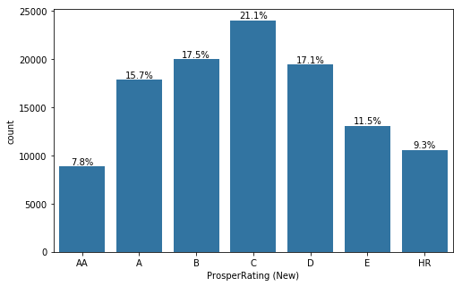

```python
#plot a seaborn countplot to determine the count of each rating category
plt.figure(figsize =[8,5])
sb.countplot(data = prosperloan, x ='ProsperRating (New)', color = sb.color_palette()[0], order = ['AA', 'A', 'B', 'C','D', 'E', 'HR'])
rating_count = prosperloan['ProsperRating (New)'].value_counts()
n_rating = prosperloan['ProsperRating (New)'].value_counts().sum()
locs, labels = plt.xticks()
for loc, label in zip(locs, labels):
    count = rating_count[label.get_text()]
    plotstring = '{:0.1f}%'. format(100*count/n_rating)
    plt.text(loc, count+200, plotstring, ha = 'center', color ='black')
```

## Observation

From the bar chart we can see that the prosper rating with the highest count in the data set is a C rating. The high risk rating (HR) is only 9% of the data set and the low risk rating (AA) is 7.8%

## Question 2:

How many borrowers fall into each income range?

## Code

```python
#get the count of borrowers in each income range
prosperloan['IncomeRange'].value_counts()
```

```
$25,000-49,999    32152
$50,000-74,999    31005
$100,000+         17321
$75,000-99,999    16899
Not displayed      7741
$1-24,999          7261
Not employed        806
$0                  621
Name: IncomeRange, dtype: int64
```

```python
#replace the not employed category with $0
prosperloan['IncomeRange'].replace('Not employed', '$0', inplace=True)
```

```python
#confirm that the replacement has been done
prosperloan['IncomeRange'].value_counts()
```

```
$25,000-49,999    32152
$50,000-74,999    31005
$100,000+         17321
$75,000-99,999    16899
Not displayed      7741
$1-24,999          7261
$0                 1427
Name: IncomeRange, dtype: int64
```

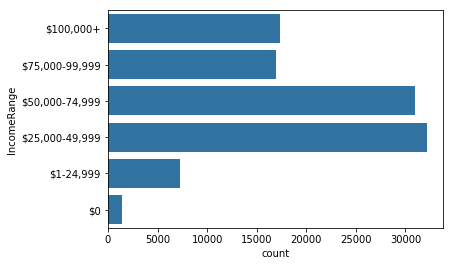

```python
#plot the horizontal bar chart to show how many borrowers fall into each Income range
sb.countplot(data=prosperloan, y= 'IncomeRange', color = sb.color_palette()[0], order = ['$100,000+', '$75,000-99,999', '$50,000-74,999','$25,000-49,999', '$1-24,999', '$0'])
```

## Observation

From this horizontal bar chart we can see that most of the borrowing is done by individuals that have an income range of 25,000 -49,999 followed closely by individuals with income range of $50,000-74,999.

## Question 3

What is the distribution of BorrowerAPR and BorrowerRate in the dataset?

## Code

```
Text(0.5,0,'BorrowerRate')
```

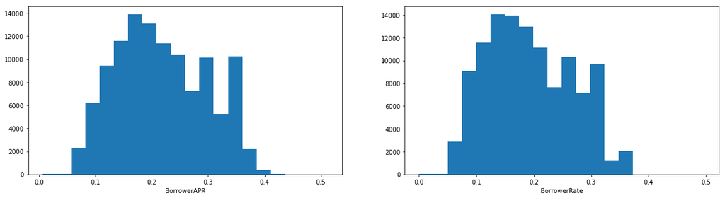

```python
#plot a histogram to show the distribution of borrowerapr and borrowerrate
plt.figure(figsize = [20, 5]);
plt.subplot(1, 2, 1)
plt.hist(data=prosperloan, x = 'BorrowerAPR', bins = 20);
plt.xlabel('BorrowerAPR')

plt.subplot(1, 2, 2)
plt.hist(data=prosperloan, x ='BorrowerRate', bins =20);
plt.xlabel('BorrowerRate')
```

## Observation

The histogram of BorrowerAPR'S in the dataset is a mesokurtic multimodal distribution with a mean of about 0.2 and the APR with the highest count in the dataset falls with 0.15 and 0.18. The BorrowerRate histogram is also very similar to the BorrowerAPR distribution. It is also a mesokurtic multimodal distribution. This could be explained by the fact that the BorrowerAPR = BorrowerRate + BorrowerFees

## Question 4:

What percentage of individuals falls into each employment status category?

## Code

```python
#find out if there are null values in the employment status column
prosperloan['EmploymentStatus'].isnull().any()
```

```
False
```

```python
#get the count of borrowers in each category
status_count = prosperloan['EmploymentStatus'].value_counts()
```

```python
#get the total amount of borrowers with an employment status in the dataset
status_total = prosperloan['EmploymentStatus'].value_counts().sum()
```

```python
#get the index of each category
status_order = status_count.index
```

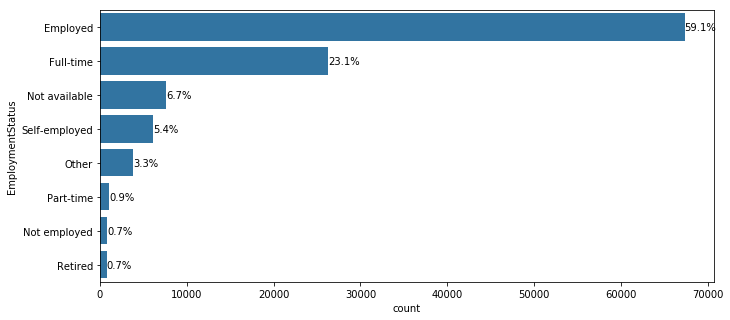

```python
#plot a bar chart showing the count of each employment status and annotate it's perecentage
plt.figure(figsize=[11,5])
sb.countplot(data=prosperloan, y ='EmploymentStatus', color = sb.color_palette()[0], order =status_order)
for i in range (status_count.shape[0]):
    count = status_count[i]
    plotstring = '{:0.1f}%'.format(100*count/status_total)
    plt.text(count+2, i, plotstring, va ='center')
```

## Observation

From the plot we can see that only a small percentage of the dataset (0.7%) are not employed, most borrowers are employed in some capacity either fulltime, partime or selfemployed. About 6.7% of borrowers did not provide information about their employment status and are categorized as not available and only 0.7 % of borroweras are retired

## Question 5:

What is the distribution of monthly payments in the dataset?

## Code

```
Text(0,0.5,'count')
```

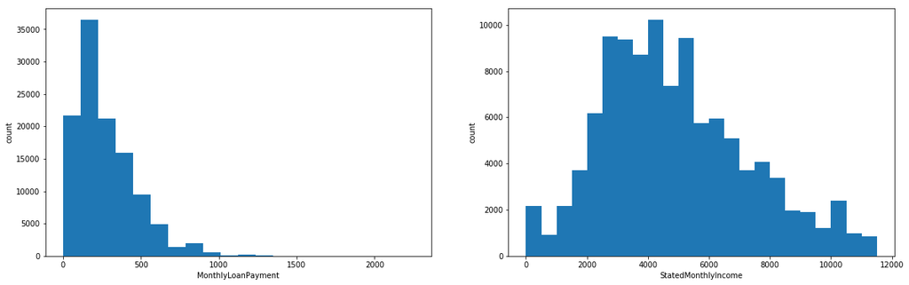

```python
#plot a histogram showing the distribution of monthly loans in the dataset
plt.figure(figsize=[20,6])

plt.subplot(1, 2, 1)
plt.hist(data=prosperloan, x = 'MonthlyLoanPayment', bins = 20);
plt.xlabel('MonthlyLoanPayment')
plt.ylabel('count')

plt.subplot(1, 2, 2)
bins = np.arange(0, prosperloan['StatedMonthlyIncome'].describe()[6]+5000, 500)
plt.hist(data=prosperloan, x = 'StatedMonthlyIncome', bins = bins);
plt.xlabel('StatedMonthlyIncome')
plt.ylabel('count')
```

## Observation

The Monthly loan payment distribution is a leptokurtic right skewed distribution with an extreme peak between 100-200 dollars. I will be exploring how these Monthly loan payments relate to the Loan Original Amount and the Term in the multivariate exploration section of this section. The Stated Monthly Income is multimodal distribution that is also right skewed. This is due some very large stated income values.

### Of the features you investigated, were there any unusual distributions? Did you perform any operations on the data to tidy, adjust, or change the form of the data? If so, why did you do this?

- From the analysis of the data we can see that ProsperRating(alpha) that is only applicable to loans post July 2009 is very similar to the CreditGrade used for pre 2009 loans. So I replaced the NC (no credit) credit grade with HR (high risk) credit grade and merged these columns.
- I also calculated the 25 missing BorrowerAPR values by adding the mean loan fees to their borrower rate.
- The histogram showing the distribution of the stated monthly income had such a wide spread of values. Because of the extreme value like the maximum value being 1,750,000,000 and the median being about 5600, I limited the bins to only show the spread of values for values in the range minimum stated monthly income to a little above the 75th percentile so I could capture as much off the distribution in my visualization and get rid of the outliers.
- I also replaced all not employed income range category with 0 dollars because unemployed people aren't making any money and there was already a $\0 category in the dataset.

## Bivariate Exploration

> In this section, I will investigate relationships between pairs of variables in the data. Variables covered here have been introduced in some fashion in the previous section (univariate exploration).

## Question 6:

What is the relationship between the debt to income ratio and the income range?

## Code

```python
#create a copy of the dataset
prosperloan2 = prosperloan.copy()
```

If the income is 0 the debt to income ratio will be really large because you're technically borrowing money for everything and will lead to a lot of outliers in the plot. So I will be dropping all rows with income rate 0 and income range not displayed

```python
#drop all rows where income rows fall into the not displayed category and $0 income rate
prosperloan2.drop(prosperloan2.index[prosperloan2['IncomeRange']=='$0'], inplace=True)
prosperloan2.drop(prosperloan2.index[prosperloan2['IncomeRange']=='Not displayed'], inplace=True)
```

```python
#confirm these rows have been dropped
prosperloan2['IncomeRange'].value_counts()
```

```
$25,000-49,999    32152
$50,000-74,999    31005
$100,000+         17321
$75,000-99,999    16899
$1-24,999          7261
Name: IncomeRange, dtype: int64
```

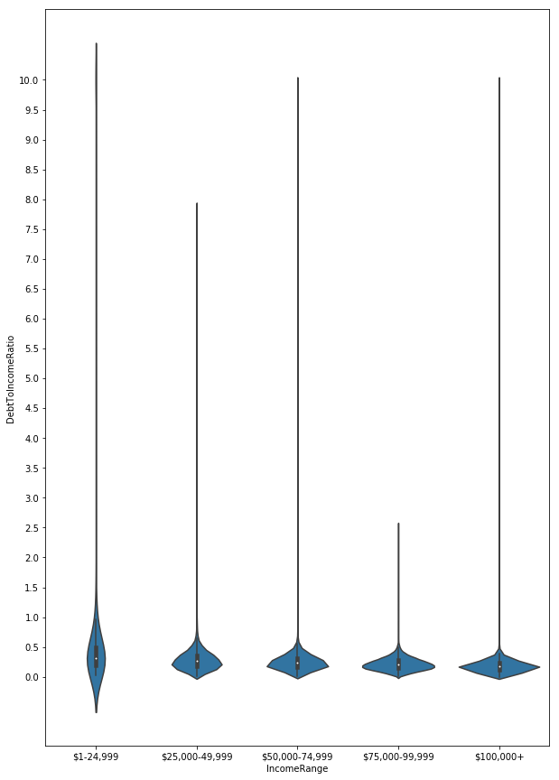

```python
#convert the income range olumn to a categorical variable
income_range = ['$1-24,999','$25,000-49,999','$50,000-74,999','$75,000-99,999','$100,000+']
incomeclasses = pd.api.types.CategoricalDtype(ordered=True, categories=income_range)
prosperloan2['IncomeRange'] = prosperloan2['IncomeRange'].astype(incomeclasses);

#make a box plot that shows the relationship between the debt to income ratio and the income ranges
plt.figure(figsize=[10,15])
sb.violinplot(data=prosperloan2, x = 'IncomeRange', y ='DebtToIncomeRatio', color = sb.color_palette()[0])
plt.yticks(np.arange(0, 10.01, 0.5));
```

## Observation

The spread of debt to income ratios are similar for all income ranges except 1-24,999 income range which has a wider spread.

## Question 7:

What is the count of income ranges in each Prosper rating category?

## Code

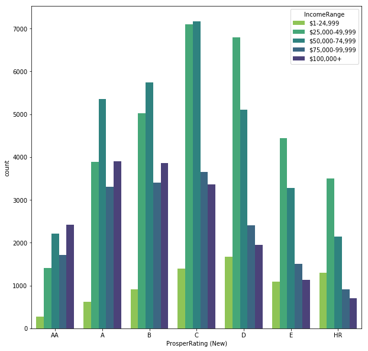

```python
#convert the prosper rating column to a categorical variable
prosperrating = ['AA', 'A', 'B', 'C', 'D','E', 'HR']
prosperclasses = pd.api.types.CategoricalDtype(ordered=True, categories = prosperrating)
prosperloan2['ProsperRating (New)'] = prosperloan2['ProsperRating (New)'].astype(prosperclasses);

#plot a clustered bar chart to see the relationship of income range with each rating category
plt.figure(figsize=[10,10])
sb.countplot(data=prosperloan2, x = 'ProsperRating (New)', hue = 'IncomeRange', palette = 'viridis_r')
```

## Observation:

From the AA, A, B prosper category, we can see that very few low income earners (1-24,999) fall into high prosper rating categories. The HR prosper rating has very little high income earners in it's category. The C prosper rating has a large amount of middle income classes (25,000-49,999 and 50, 000-74,999).

## Question 8:

What is the average principal loss for ChargedOff and Defaulted Loans?

## Code

```python
prosperloan3 = prosperloan.copy()
```

```python
#filter out the categories that make losses and convert them to categorical variables
loan_status = ['Defaulted', 'Chargedoff']
loanclasses = pd.api.types.CategoricalDtype(ordered=True, categories = loan_status)
prosperloan3['LoanStatus'] = prosperloan3['LoanStatus'].astype(loanclasses)
```

```
Text(0,0.5,'Mean LP_GrossPrincipalLoss')
```

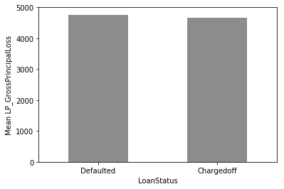

```python
#group these loans by the loan status and plot the a bar chart that shows the mean of their gross principal loss
prosperloan3.groupby('LoanStatus')['LP_GrossPrincipalLoss'].mean().plot(kind='bar', color = '0.55')
plt.xticks(rotation=360)
plt.ylabel('Mean LP_GrossPrincipalLoss')
```

## Observation:

Defaulted loans have a slightly higher mean LP_GrossPrincipalLoss than Chargedoff loans

## Question 9:

What is the relationship with some of the quantitative variables in the dataset?

## Code

```python
#make a list of the variables I'm interested in exploring
quantitative_vars = [ 'BorrowerAPR', 'LenderYield','MonthlyLoanPayment','EstimatedReturn']
```

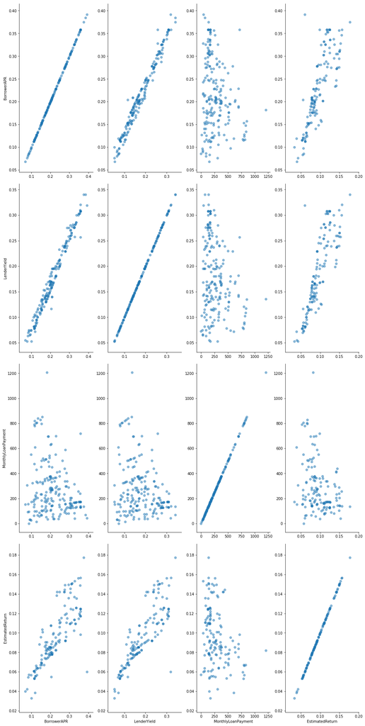

```python
#get a random sample of the data set to avoid overplotting

sample = np.random.choice(prosperloan.shape[0], 200, replace=False)
prosperloan_subset = prosperloan.loc[sample,:]

#use the pairgrid to plot all the relationships with these variables at once
g = sb.PairGrid(data=prosperloan_subset, vars = quantitative_vars, size =7, aspect =0.5)
g.map(plt.scatter, alpha = 1/2)
```

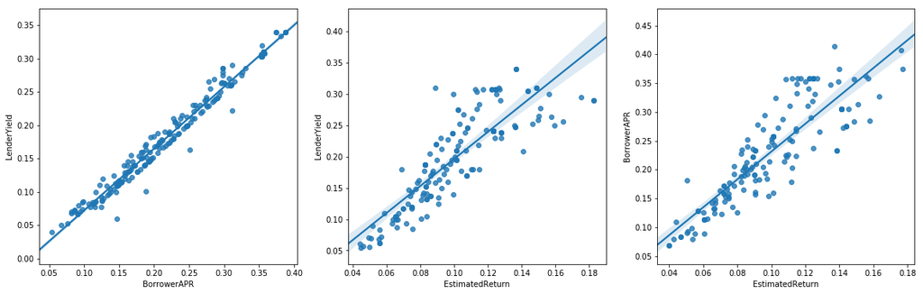

```python
#expand the plots of interest from the pairgrid above
plt.figure(figsize=[20,6])

plt.subplot(1, 3, 1)
sb.regplot(data=prosperloan.sample(200), x='BorrowerAPR', y='LenderYield')

plt.subplot(1, 3, 2)
sb.regplot(data=prosperloan.sample(200), x='EstimatedReturn',  y = 'LenderYield')

plt.subplot(1,3,3)
sb.regplot(data=prosperloan.sample(200), x = 'EstimatedReturn', y ='BorrowerAPR')
```

## Observation

The scatter plot I would be focusing on is the one that displays the relationship between the BorrowerAPR and LenderYield. This plot shows a positve correlation between the BorrowerAPR and the LenderYield which means that as the BorrowerAPR increases so does the LenderYield. There also seems to be a positive correlation between the lender yield and the estimated return and the estimated return and borrowerapr The other scatter plots displayed don't seem to have any correlation.

## Question 10:

What is the correlation between the loan orignal amount and the monthly loan payment? What is the correlation between the loan original amount and Stated Monthly income?

## Code

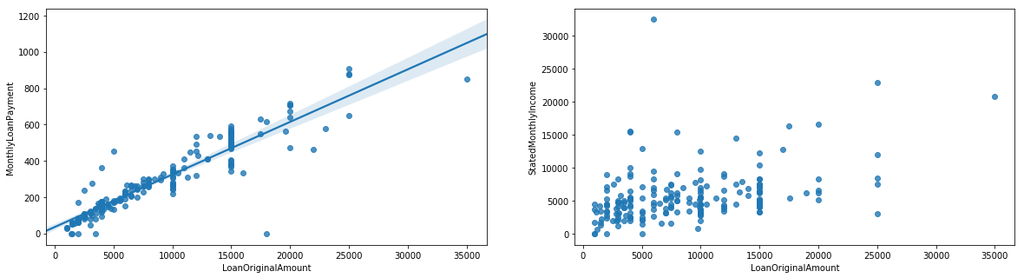

```python
#make a plot that shows the correlation between the LoanOriginalAmount and MOnthlyLoanPayment
plt.figure(figsize=[20,5])
plt.subplot(1,2,1)
sb.regplot(data=prosperloan.sample(200), x='LoanOriginalAmount', y='MonthlyLoanPayment')


#make a plot that shows the correlation between the LoanOriginalAmount and StatedMonthlyIncome
plt.subplot(1, 2, 2)
sb.regplot(data=prosperloan.sample(200), x='LoanOriginalAmount', y='StatedMonthlyIncome', fit_reg=False)
```

## Observation:

There is a positve correlation between the Loan original amount and the monthly loan payments. There is no correlation between the the stated monthly income and the loan original amount.

## Question 11:

What is the count of loan status in each prosper rating category?

## Code

```python
#create a copy of the dataset
prosperloan4 =prosperloan.copy()
```

```python
#convert the status I.m interested in to categorical variables
loanstatus = ['Current', 'Completed', 'Defaulted']
loanclass = pd.api.types.CategoricalDtype(ordered=True, categories=loanstatus)
prosperloan4['LoanStatus'] = prosperloan4['LoanStatus'].astype(loanclass)
```

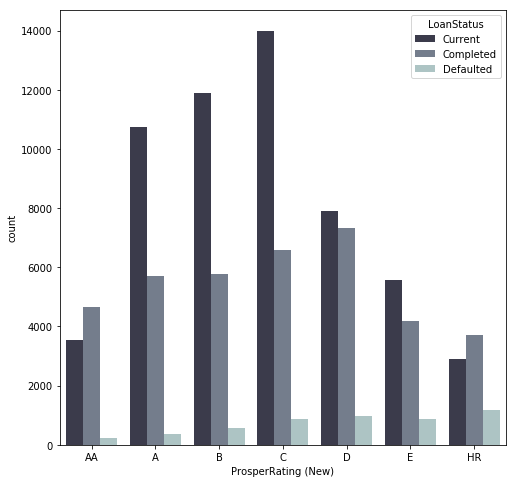

```python
#plot a clustered bar chart that shows the count of each loan status in each prosper rating category
plt.figure(figsize=[8,8])
sb.countplot(data=prosperloan4, x='ProsperRating (New)', hue = 'LoanStatus', palette = 'bone', order =['AA', 'A','B','C','D','E','HR'])
```

## Obsevation

The defaulted loans are very few for AA category and increase as the ratings go towards the HR category. All categories have their current count higher that their completed count except the HR and AA category.

## Question 12:

How does the prosper rating affect the estimated return?

## Code :

```python
#get the location of the xticks
inds = np.arange(len(prosperloan['ProsperRating (New)'].unique()))
#state the labels
labels =['AA','A','B','C','D','E','HR']
```

```
Text(0.5,1,'Average Estimated Return vs Prosper Rating Categories')
```

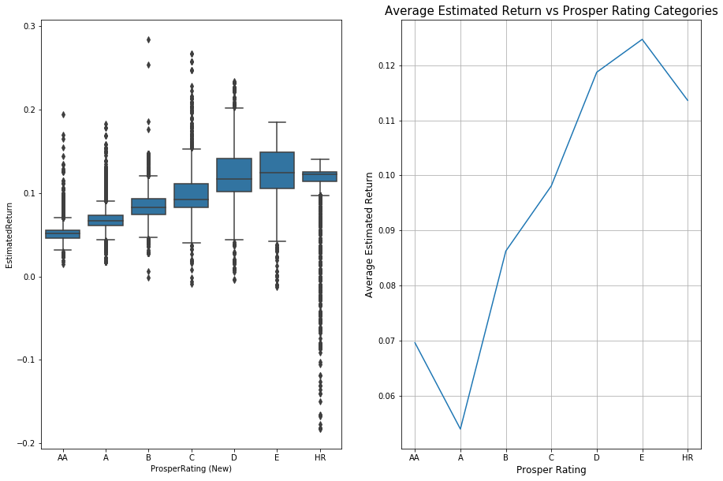

```python
#get a boxplot of the relationship between prosper rating and estimated return
plt.figure(figsize=[15,10])
plt.subplot(1,2,1)
sb.boxplot(data=prosperloan, x='ProsperRating (New)', y='EstimatedReturn', order =['AA','A','B','C','D','E','HR'], color = sb.color_palette()[0] )
#plot the average estimated return vs the propser rating categories.

plt.subplot(1,2,2)
prosperloan.groupby('ProsperRating (New)')['EstimatedReturn'].mean().plot(kind='line')
plt.grid()
plt.xticks(inds, labels,fontsize=10);
plt.xlabel('Prosper Rating', fontsize=12)
plt.ylabel('Average Estimated Return', fontsize=12)
plt.title('Average Estimated Return vs Prosper Rating Categories', fontsize=15)
```

## Observation:

The plots shift higher on the estimated return axis as the prosper rating reduces indicating that loan categories with high risk D,E and HR have higher estimated returns that lower risk categories, AA, A and B

## Question 13:

What is the trend in BorrowerAPR and EstimatedReturn from year to year?

## Code

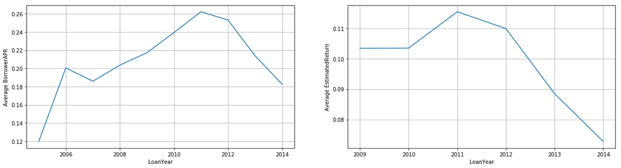

```python
#specify the size of the figure to be plotted
plt.figure(figsize =[20,5])

plt.subplot(1, 2, 1 )
#group the dataset by the Loan year and plot that against the average borrowerAPR
prosperloan.groupby('LoanYear')['BorrowerAPR'].mean().plot(kind='line')
plt.ylabel('Average BorrowerAPR')
plt.grid()

plt.subplot(1, 2, 2)
#group the dataset by the loan year and plot that against the average estimated return (only applicable to loans post 2009)
prosperloan.groupby('LoanYear')['EstimatedReturn'].mean().plot(kind='line')
plt.ylabel('Average EstimatedReturn')
plt.grid()
```

## Observation:

Average BorrowerAPR is at it's lowest in 2005 and highest in 2011. Average EstimatedReturn was about the same from 2009 to 2010 , was at it's maximum at 2011 and there was a steady decline in average estimated return from 2011-2014

#### I observed that both the estimated return and borrower APR had their highest value in 2011. Since I already figure out in questionn 12 that higher risk prosper rating categories had higher estimated returns. I wanted to figure out if the year 2011 had more D,E and HR loans than the other years

## Question 14:

Does 2011 have higher low rated prosper categories than other years?

```python
#get a data frame where all the loans are from 2011
df3 = prosperloan[prosperloan['LoanYear']==2011]
```

```python
#get a dataframe where all the loans are not from 2011
df4 = prosperloan[prosperloan['LoanYear']!=2011]
```

```python
#group the 2011 dataframe by the prosper rating categories
year2011 = df3.groupby('ProsperRating (New)').size()
```

```python
# group the other years by the prosper rating and find the average for each category by dividing it by 9 years
otheryears = df4.groupby('ProsperRating (New)').size()/9
```

```python
#make a list of all rating categories
x = ['AA','A','B','C','D','E','HR']

#make a list of the size of each category for 2011
y1 = [year2011[0], year2011[1], year2011[2], year2011[3], year2011[4], year2011[5], year2011[6]]

#make a list for the size of each category for the other years
y2 = [otheryears[0], otheryears[1], otheryears[2], otheryears[3], otheryears[4], otheryears[5], otheryears[6]]
```

```python
#specify the width of the bars
width = 0.4

#get the location of the xticks
ind = np.arange(len(prosperloan['ProsperRating (New)'].unique()))
ind

#state the labels
#labels =['AA','A','B','C','D','E','HR']
#labels
```

```
array([0, 1, 2, 3, 4, 5, 6])
```

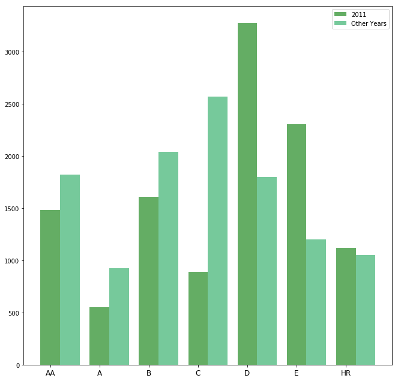

```python
#make a bar plot to show the count of year 2011 and other years for each rating category
plt.figure(figsize=[11,11])
Yes2011 = plt.bar(ind, year2011, width, alpha=.7, color='forestgreen')
Not2011= plt.bar(ind+width, otheryears, width, alpha=.7, color='mediumseagreen')
plt.legend(['2011', 'Other Years'])
plt.xticks(ind, labels,fontsize=12);
```

## Observation:

We can clearly see that 2011 has more loans with low prosper ratings D,E and HR than other years.

## Question 15:

What is the distribution of the BorrowerAPR from year to year?

## Code

```python
prosperloan.LoanYear.value_counts()
```

```
2013    34345
2012    19553
2014    12172
2008    11552
2007    11460
2011    11228
2006     5906
2010     5579
2009     1989
2005       22
Name: LoanYear, dtype: int64
```

```python
prosperloan.LoanYear.dtypes
```

```
dtype('int64')
```

```python
loanyear =[2005,2006,2007,2008,2009,2010,2011,2012,2013,2014]
yearclasses = pd.api.types.CategoricalDtype(ordered=True, categories=loanyear)
prosperloan['LoanYear'] = prosperloan['LoanYear'].astype(yearclasses)
```

```python
prosperloan['LoanYear'].dtypes
```

```
CategoricalDtype(categories=[2005, 2006, 2007, 2008, 2009, 2010, 2011, 2012, 2013, 2014], ordered=True)
```

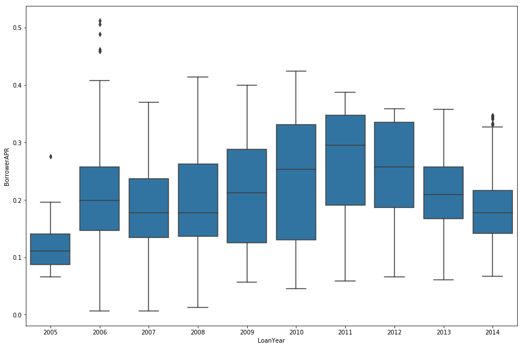

```python
#plot a violin plot for Borrower APR for each year
plt.figure(figsize=[15,10])
sb.boxplot(data=prosperloan, x='LoanYear', y='BorrowerAPR', color=sb.color_palette()[0])
```

## Observation:

BorrowerApr has it's lowest spread in 2005 and highest spread in 2010. 2011 has the highest median APR value.

### Talk about some of the relationships you observed in this part of the investigation. How did the feature(s) of interest vary with other features in the dataset?

- The spread of debt to income rations are similar for all income ranges except 1-24,999 income range which has a wider spread.
- Very few low income earners (1-24,999) fall into high prosper rating categories (AA, A and B). The HR prosper rating has very little high income earners in it's category. The C prosper rating has a large amount of middle income classes (25,000-49,999 and 50, 000-74,999).
- Average Loss on defaulted loans is only slightly higher than average loss on charged off loans.
- There is a positive correlation between estimated return and the borroweAPR and also the lender yield and borrowerAPR.
- There is a positive correlation between the loan original amount and the monthly loan payment.
- The defaulted loans are very few for AA category and increase as the ratings go towards the HR category
- Average BorrowerAPR is at it's lowest in 2005 and highest in 2011. Average EstimatedReturn was about the same from 2009 to 2010 , was at it's maximum at 2011 and there was a steady decline in average estimated return from 2011-2014.
- 2011 had more lower rated loans than other years.
- BorrowerAPR has it's lowest spread in 2005 and highest spread in 2010. 2011 has the highest median APR value. ### Did you observe any interesting relationships between the other features (not the main feature(s) of interest)?
- I've always believed that loans are given out based on your monthly income since your monthly income is a reflection of our ability to pay back the loan. So it was so interesting to me that there was no correlation between the loan original amount and the stated monthly income in this dataset.
- There is a positive correlation between the lender yield and the estimated return.

## Multivariate Exploration

> In this section, I would create plots of three or more variables to investigate the data even further.

## Question 16:

What is the correlation between the loan original amount, monthly loan payment and the loan term?

## Code

```python
#set the start point
np.random.seed(0)
```

```python
#convert the loan term column to a categorical variable
prosperterm =[36, 60, 12]
termclasses = pd.api.types.CategoricalDtype(ordered=True, categories = prosperterm)
prosperloan['Term'] = prosperloan['Term'].astype(termclasses)
```

```
Text(27.2379,0.5,'Monthly loan payment')
```

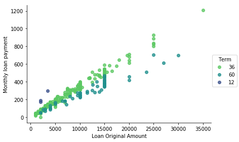

```python
#get a subset of the data to avoid over plotting
sample = np.random.choice(prosperloan.shape[0], 300, replace=False)
prosperloan_subset = prosperloan.loc[sample]

#plot the relationship between loan original amount, monthly loan payment and term on a scatter plot using color as the encoding
g= sb.FacetGrid(data = prosperloan_subset, hue = 'Term', size=4, aspect=1.5, palette ='viridis_r')
g.map(sb.regplot, 'LoanOriginalAmount', 'MonthlyLoanPayment', x_jitter = 0.04, fit_reg = False)
g.add_legend()
plt.xlabel('Loan Original Amount')
plt.ylabel('Monthly loan payment')
```

## Observation:

There are a lot more 36 month term loans in the dataset than any other category. The 12 month termed loans are not a lot and have a smaller spread of loan original amounts with none of the data points exceeding 10000 dollars and they seem to have higher monthly loan payments when compared to equal loan original amounts for other term categories. The 60 month term has lower monthly payments than the 36 month term and the 12 month term.

## Question 17:

What is the correlation between the loan original amount, monthly loan payment and the prosper rating?

## Code

```
Text(35.4587,0.5,'Monthly loan payment')
```

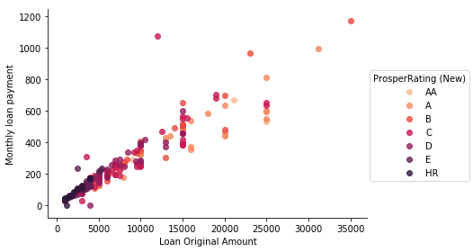

```python
#get a sample of the dataset
sample = np.random.choice(prosperloan.shape[0], 250, replace=False)
prosperloan_subset = prosperloan.loc[sample]

#plot the relationship between loan original amount, monthly loan payment and prosper rating on a scatter plot using color as the encoding
g= sb.FacetGrid(data = prosperloan_subset, hue = 'ProsperRating (New)', hue_order = ['AA','A','B','C','D','E','HR'], size=4, aspect=1.5, palette ='rocket_r')
g.map(sb.regplot, 'LoanOriginalAmount', 'MonthlyLoanPayment', x_jitter = 0.04, fit_reg = False)
g.add_legend()
plt.xlabel('Loan Original Amount')
plt.ylabel('Monthly loan payment')
```

## Observation:

HR prosper rated individuals typically take at lower loan amounts that higher rated individuals and also have lower monthly payments. Individuals with higher prosper ratings AA, A and B typically take out higher loans and pay back higher amounts monthly as well.

## Question 18:

What is the correlation between estimated return, lenderyield and borrowerAPR?

## Code:

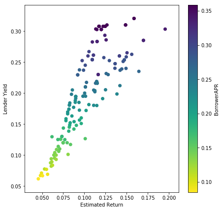

```python
#plot a scatter plot displaying the correlation between these variables using color as the encoding
plt.figure(figsize=[7,7])
plt.scatter(data=prosperloan.sample(200), x = 'EstimatedReturn', y = 'LenderYield', c = 'BorrowerAPR', cmap = 'viridis_r')
plt.xlabel('Estimated Return')
plt.ylabel('Lender Yield')
plt.colorbar(label ='BorrowerAPR')
```

## Observation:

Lender yield , estimated return and borrowerAPR are all positively correlated

## Question 19:

What the relationship between estimated return and prosper rating for each income range category?

## Code

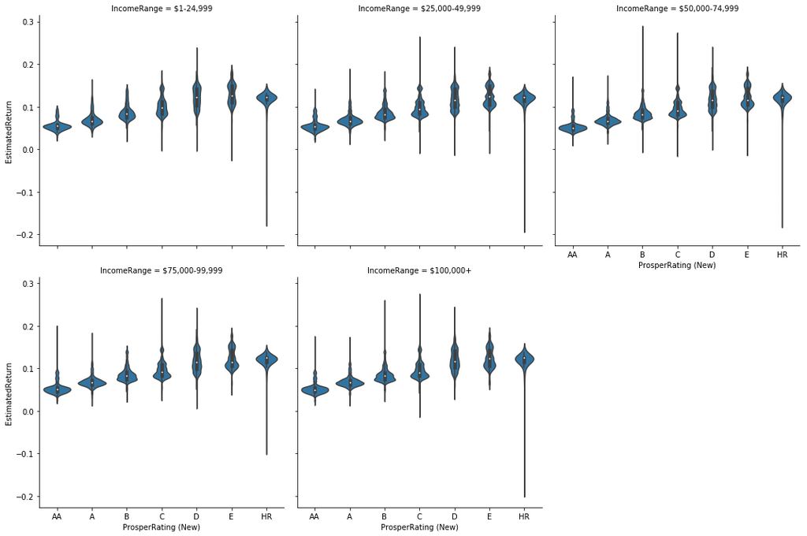

```python
#use facet grid to create subplots of each income range
g = sb.FacetGrid(data = prosperloan2, col = 'IncomeRange', size = 5, sharey=True, col_wrap = 3)

#get a boxplot of the relationship between prosper rating and estimated return
g.map(sb.violinplot, 'ProsperRating (New)', 'EstimatedReturn' )
```

The HR Prosper rating for all income groups have a lot of extreme negative estimated return values. Lower prosper rating categories have a higher average estimated return than the higher prosper rating categories for all income ranges.

## Question 20:

What is the Average APR for home owners and non-home owners all through the years 2005-2014?

## Code

```python
#create a subset of the loan data that has only home owners
df= prosperloan[prosperloan['IsBorrowerHomeowner']==True]
df.shape
```

```
(57413, 77)
```

```python
#convert the loan year column from categorical to string format
df['LoanYear'] = df['LoanYear'].astype('object')
```

```python
#create a subset of the loan data that has only non home owners
df2= prosperloan[prosperloan['IsBorrowerHomeowner']==False]
df2.shape
```

```
(56393, 77)
```

```python
#convert the loan year column from categorical to string format
df2['LoanYear'] = df2['LoanYear'].astype('object')
```

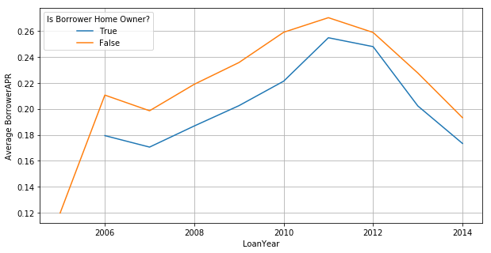

```python
#create a line plot that shows the average borrower apr from 2005-2014
plt.figure(figsize=[10,5])
df.groupby('LoanYear')['BorrowerAPR'].mean().plot(kind='line', label = 'True')
df2.groupby('LoanYear')['BorrowerAPR'].mean().plot(kind='line', label='False')
plt.ylabel('Average BorrowerAPR')
plt.xlabel('LoanYear')
plt.legend(title = 'Is Borrower Home Owner?')
plt.grid()
```

## Observation:

Average BorrowerAPR is relatively lower all through the years for Home owners than borrowers who don't have homes

## Question 21:

How does the homeowner status affect the borrowerAPR from year to year?

## Code

```python
#confirm that data type is categorical
prosperloan.LoanYear.dtypes
```

```
CategoricalDtype(categories=[2005, 2006, 2007, 2008, 2009, 2010, 2011, 2012, 2013, 2014], ordered=True)
```

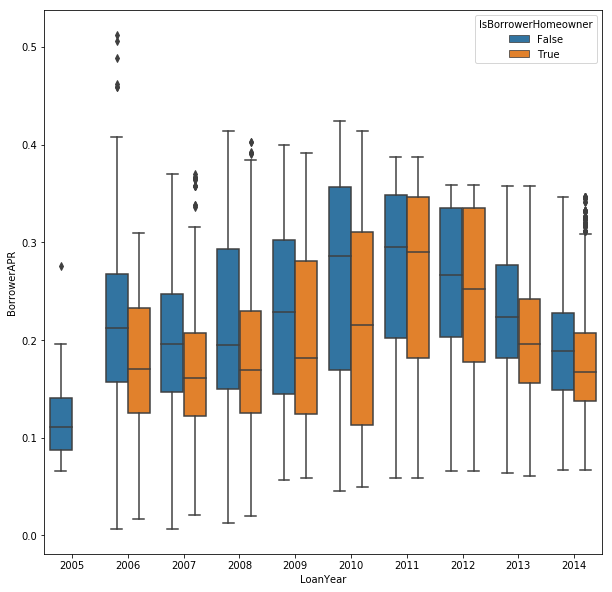

```python
#make a plot of the relationship with loan year and borrower apr for each home owner status
plt.figure(figsize=[10,10])
sb.boxplot(data=prosperloan, x = 'LoanYear', y = 'BorrowerAPR', hue = 'IsBorrowerHomeowner')
```

Looks like there were no home owners in the year 2005 in the dataset. Non-home owners third quartile borowers APR is higher than home owners borrowers APR for every year except 2011 and 2012 where they are almost exactly the same.

## Conclusion

# Limitations

- There were values in the IncomeRange column categorized as Not Displayed. I tried to input these IncomeRange by iterating through the rows of the data set and multiplying their StatedMonthlyIncome value by 12 to find out the exact income ranges they belonged to. I discovered that it was taking a really long time to iterate through the rows so I just had to drop the rows instead.
- Dataset had too many variables so it was hard to pick what variables to focus on for the analysis
- It took some time to get used to the meaning of the variables since I have no background in finance.